# IBM Stock Prices

# Exploratory Data Analysis (EDA) on IBM Stock Prices

## Introduction

In this project, we conduct an Exploratory Data Analysis (EDA) on the historical stock prices of International Business Machines Corporation (IBM). IBM is a leading multinational technology and consulting company, widely recognized for its innovations in computing and information technology solutions.

The primary objective of this EDA is to gain insights into the patterns, trends, and characteristics of IBM’s stock prices over time. By analyzing the historical data, we aim to identify potential factors influencing the stock prices, understand the volatility, and explore any significant changes or anomalies in the stock market performance of IBM.

Through a series of data processing steps, statistical analysis, and visualization techniques, we will delve into various aspects of IBM’s stock market data. This includes handling missing values, exploring temporal trends by dividing the date column into day, month, and year, and examining key statistical summaries and visualizations.

By addressing these objectives, we aim to provide valuable insights for investors, financial analysts, and stakeholders interested in understanding the dynamics of IBM’s stock market performance.

```r
library(tidyr)
library(dplyr)
```

#### **1. Load the Dataset**: Load the dataset as a dataframe, where the value 999 represents missing data, and display its first few rows, statistical summary, and column structure.

```r
#Read csv
IBM <- read.csv('C:/Users/josem/Downloads/IBM.csv', na.strings='999')

#First rows
head(IBM,5)
```

|  | Date | Open | High | Low | Close | Volume | Adj.Close |
| --- | --- | --- | --- | --- | --- | --- | --- |
| 1 | 01/03/2000 | 102.00 | 105.50 | 100.06 | 100.25 | 10807800 | 84.48 |
| 2 | 02/03/2000 | 100.50 | 105.44 | 99.50 | 103.12 | 11192900 | 86.90 |
| 3 | 03/03/2000 | 107.25 | 110.00 | 106.06 | 108.00 | 10162800 | 91.01 |
| 4 | 06/03/2000 | 109.94 | 111.00 | 101.00 | 103.06 | 10747400 | 86.85 |
| 5 | 07/03/2000 | 106.00 | 107.00 | 101.69 | 103.00 | 10035100 | 86.80 |

```r
#Statistic Sum
summary(IBM)
```

```
     Date                Open             High             Low             Close            Volume           Adj.Close
 Length:3270        Min.   : 54.65   Min.   : 56.70   Min.   : 54.01   Min.   : 55.07   Min.   : 1027500   Min.   : 47.06
 Class :character   1st Qu.: 86.56   1st Qu.: 87.56   1st Qu.: 85.75   1st Qu.: 86.56   1st Qu.: 4772625   1st Qu.: 75.25
 Mode  :character   Median :103.95   Median :105.50   Median :102.50   Median :103.98   Median : 6201000   Median : 90.75
                    Mean   :113.95   Mean   :115.15   Mean   :112.93   Mean   :114.07   Mean   : 6998023   Mean   :103.72
                    3rd Qu.:126.38   3rd Qu.:127.56   3rd Qu.:125.39   3rd Qu.:126.59   3rd Qu.: 8337500   3rd Qu.:117.58
                    Max.   :211.15   Max.   :211.79   Max.   :210.06   Max.   :211.00   Max.   :41207300   Max.   :207.19
                    NA's   :14
```

```r
#Columns Structure
str(IBM)
```

```
'data.frame':   3270 obs. of  7 variables:
 $ Date     : chr  "01/03/2000" "02/03/2000" "03/03/2000" "06/03/2000" ...
 $ Open     : num  102 100 107 110 106 ...
 $ High     : num  106 105 110 111 107 ...
 $ Low      : num  100.1 99.5 106.1 101 101.7 ...
 $ Close    : num  100 103 108 103 103 ...
 $ Volume   : int  10807800 11192900 10162800 10747400 10035100 8376400 6334100 7093200 7871000 7973700 ...
 $ Adj.Close: num  84.5 86.9 91 86.8 86.8 ...
```

#### **2. Replace Null Values**: Replace all null values in the “Open” column with its median.

```r
#Identifiyin Null
apply(is.na(IBM),2,sum)
```

```
     Date      Open      High       Low     Close    Volume Adj.Close
        0        14         0         0         0         0         0
```

**Solo una columna?**

```r
#Median Open
mediana_open <- median(IBM$Open, na.rm = TRUE)

#Replace nulls
IBM$Open <- ifelse(is.na(IBM$Open), mediana_open, IBM$Open)

#Validating nulls off
apply(is.na(IBM),2,sum)
```

```
     Date      Open      High       Low     Close    Volume Adj.Close
        0         0         0         0         0         0         0
```

#### **3. Split the Date Column**: Divide the “Date” column into “Day”, “Month”, and “Year”.

```r
IBM<-separate(IBM, Date, into = c("day", "month", "year"), sep = "/", remove = F)
```

#### **4. Convert Year to Factor**: Change the “Year” column to a factor.

```r
as.factor(IBM$year)
```

```
   [1] 2000 2000 2000 2000 2000 2000 2000 2000 2000 2000 2000 2000 2000 2000 2000 2000 2000 2000 2000 2000 2000 2000 2000 2000
  [25] 2000 2000 2000 2000 2000 2000 2000 2000 2000 2000 2000 2000 2000 2000 2000 2000 2000 2000 2000 2000 2000 2000 2000 2000
  [49] 2000 2000 2000 2000 2000 2000 2000 2000 2000 2000 2000 2000 2000 2000 2000 2000 2000 2000 2000 2000 2000 2000 2000 2000
  [73] 2000 2000 2000 2000 2000 2000 2000 2000 2000 2000 2000 2000 2000 2000 2000 2000 2000 2000 2000 2000 2000 2000 2000 2000
  [97] 2000 2000 2000 2000 2000 2000 2000 2000 2000 2000 2000 2000 2000 2000 2000 2000 2000 2000 2000 2000 2000 2000 2000 2000
 [121] 2000 2000 2000 2000 2000 2000 2000 2000 2000 2000 2000 2000 2000 2000 2000 2000 2000 2000 2000 2000 2000 2000 2000 2000
 [145] 2000 2000 2000 2000 2000 2000 2000 2000 2000 2000 2000 2000 2000 2000 2000 2000 2000 2000 2000 2000 2000 2000 2000 2000
 [169] 2000 2000 2000 2000 2000 2000 2000 2000 2000 2000 2000 2000 2000 2000 2000 2000 2000 2000 2000 2000 2000 2000 2000 2000
 [193] 2000 2000 2000 2000 2000 2000 2000 2000 2000 2000 2000 2000 2000 2000 2000 2000 2000 2000 2000 2000 2001 2001 2001 2001
 [217] 2001 2001 2001 2001 2001 2001 2001 2001 2001 2001 2001 2001 2001 2001 2001 2001 2001 2001 2001 2001 2001 2001 2001 2001
 [241] 2001 2001 2001 2001 2001 2001 2001 2001 2001 2001 2001 2001 2001 2001 2001 2001 2001 2001 2001 2001 2001 2001 2001 2001
 [265] 2001 2001 2001 2001 2001 2001 2001 2001 2001 2001 2001 2001 2001 2001 2001 2001 2001 2001 2001 2001 2001 2001 2001 2001
 [289] 2001 2001 2001 2001 2001 2001 2001 2001 2001 2001 2001 2001 2001 2001 2001 2001 2001 2001 2001 2001 2001 2001 2001 2001
 [313] 2001 2001 2001 2001 2001 2001 2001 2001 2001 2001 2001 2001 2001 2001 2001 2001 2001 2001 2001 2001 2001 2001 2001 2001
 [337] 2001 2001 2001 2001 2001 2001 2001 2001 2001 2001 2001 2001 2001 2001 2001 2001 2001 2001 2001 2001 2001 2001 2001 2001
```

[output cut: 29 more lines]

#### **5. Return Highest Price of Each Year**: Obtain the highest price for each year.

```r
IBM %>%
  select(year, High) %>%
  group_by(year) %>%
  summarise(max_high_price = max(High))
```

| year | max_high_price |
| --- | --- |
| 2000 | 134.94 |
| 2001 | 124.70 |
| 2002 | 126.39 |
| 2003 | 94.54 |
| 2004 | 100.43 |
| 2005 | 99.10 |
| 2006 | 97.88 |
| 2007 | 121.46 |
| 2008 | 130.93 |
| 2009 | 132.85 |

[output cut: 4 more lines]

#### **6. Show Frequency Table for Each Year**: Display a frequency table for each year.

**Se puede obtener con %**

```r
IBM %>%
  group_by(year) %>%
  summarise(total_year = n())
```

| year | total_year |
| --- | --- |
| 2000 | 212 |
| 2001 | 248 |
| 2002 | 252 |
| 2003 | 252 |
| 2004 | 252 |
| 2005 | 252 |
| 2006 | 251 |
| 2007 | 251 |
| 2008 | 253 |
| 2009 | 252 |

[output cut: 4 more lines]

#### **7. Calculate Differences**: Create a new column named “Differences” containing the difference between the highest and lowest prices.

```r
IBM <- mutate(IBM,Differences=High-Low)

print(IBM)
```

| Date | day | month | year | Open | High | Low | Close | Volume | Adj.Close | Differences |
| --- | --- | --- | --- | --- | --- | --- | --- | --- | --- | --- |
| 01/03/2000 | 01 | 03 | 2000 | 102.00 | 105.50 | 100.06 | 100.25 | 10807800 | 84.48 | 5.44 |
| 02/03/2000 | 02 | 03 | 2000 | 100.50 | 105.44 | 99.50 | 103.12 | 11192900 | 86.90 | 5.94 |
| 03/03/2000 | 03 | 03 | 2000 | 107.25 | 110.00 | 106.06 | 108.00 | 10162800 | 91.01 | 3.94 |
| 06/03/2000 | 06 | 03 | 2000 | 109.94 | 111.00 | 101.00 | 103.06 | 10747400 | 86.85 | 10.00 |
| 07/03/2000 | 07 | 03 | 2000 | 106.00 | 107.00 | 101.69 | 103.00 | 10035100 | 86.80 | 5.31 |
| 08/03/2000 | 08 | 03 | 2000 | 103.00 | 106.87 | 102.75 | 106.25 | 8376400 | 89.53 | 4.12 |
| 09/03/2000 | 09 | 03 | 2000 | 106.50 | 108.00 | 104.12 | 108.00 | 6334100 | 91.01 | 3.88 |
| 10/03/2000 | 10 | 03 | 2000 | 107.62 | 109.00 | 105.00 | 105.25 | 7093200 | 88.69 | 4.00 |
| 13/03/2000 | 13 | 03 | 2000 | 104.00 | 109.00 | 102.50 | 107.69 | 7871000 | 90.75 | 6.50 |
| 14/03/2000 | 14 | 03 | 2000 | 107.75 | 110.00 | 107.37 | 108.62 | 7973700 | 91.53 | 2.63 |

[output cut: 990 more lines]

#### **8. Sort Dataset**: Sort the dataset in ascending order based on the “Differences” column.

```r
IBM <- sort_by(IBM,IBM$Differences)

print(IBM)
```

|  | Date | day | month | year | Open | High | Low | Close | Volume | Adj.Close | Differences |
| --- | --- | --- | --- | --- | --- | --- | --- | --- | --- | --- | --- |
| 1128 | 26/08/2004 | 26 | 08 | 2004 | 85.00 | 85.04 | 84.69 | 84.69 | 3134400 | 73.48 | 0.35 |
| 1255 | 28/02/2005 | 28 | 02 | 2005 | 92.53 | 92.76 | 92.41 | 92.58 | 4949800 | 80.63 | 0.35 |
| 1129 | 27/08/2004 | 27 | 08 | 2004 | 84.65 | 84.95 | 84.59 | 84.94 | 2444800 | 73.70 | 0.36 |
| 2463 | 14/12/2009 | 14 | 12 | 2009 | 129.65 | 129.98 | 129.60 | 129.93 | 5201300 | 121.60 | 0.38 |
| 1216 | 31/12/2004 | 31 | 12 | 2004 | 98.60 | 98.91 | 98.49 | 98.58 | 2793200 | 85.70 | 0.42 |
| 1149 | 27/09/2004 | 27 | 09 | 2004 | 84.10 | 84.44 | 83.98 | 84.16 | 4650300 | 73.02 | 0.46 |
| 1059 | 18/05/2004 | 18 | 05 | 2004 | 86.08 | 86.49 | 86.00 | 86.06 | 4401100 | 74.51 | 0.49 |
| 1079 | 17/06/2004 | 17 | 06 | 2004 | 90.50 | 90.56 | 90.07 | 90.44 | 4180200 | 78.30 | 0.49 |
| 1211 | 23/12/2004 | 23 | 12 | 2004 | 97.50 | 98.00 | 97.50 | 97.72 | 3590600 | 84.95 | 0.50 |
| 1358 | 26/07/2005 | 26 | 07 | 2005 | 84.15 | 84.35 | 83.85 | 84.12 | 4542900 | 73.46 | 0.50 |

[output cut: 990 more lines]

#### **9. Statistical Summary by Year**: Display a statistical summary of the dataset for each year, including the highest opening price, lowest closing price, mean of the “Differences” column, and the number of elements for each year.

```r
IBM %>%
  select(year,Open,Close,Differences) %>%
  group_by(year) %>%
  summarise(max_open_price = max(Open),
            min_close_price = min(Close),
            mean_diff = mean(Differences),
            total_year_values = n())
```

| year | max_open_price | min_close_price | mean_diff | total_year_values |
| --- | --- | --- | --- | --- |
| 2000 | 133.06 | 81.56 | 4.143868 | 212 |
| 2001 | 123.89 | 84.81 | 3.105806 | 248 |
| 2002 | 125.00 | 55.07 | 2.513611 | 252 |
| 2003 | 93.90 | 75.18 | 1.558135 | 252 |
| 2004 | 103.95 | 82.21 | 1.212143 | 252 |
| 2005 | 98.97 | 72.01 | 1.186825 | 252 |
| 2006 | 103.95 | 73.57 | 1.123745 | 251 |
| 2007 | 119.31 | 90.90 | 1.849163 | 251 |
| 2008 | 129.83 | 71.74 | 3.317352 | 253 |
| 2009 | 132.41 | 81.98 | 2.174524 | 252 |

[output cut: 4 more lines]

#### **10. Sum of Volume**: Show the sum of the Volume variable for all years.

```r
IBM %>%
  select(year,Volume) %>%
  group_by(year) %>%
  summarise(sum_volume = sum(Volume))
```

| year | sum_volume |
| --- | --- |
| 2000 | 1524122700 |
| 2001 | 2125060300 |
| 2002 | 2347246300 |
| 2003 | 1853423000 |
| 2004 | 1316247600 |
| 2005 | 1539128900 |
| 2006 | 1455782200 |
| 2007 | 2019185700 |
| 2008 | 2377449700 |
| 2009 | 2084230400 |

[output cut: 4 more lines]

```r
library(ggplot2)
```

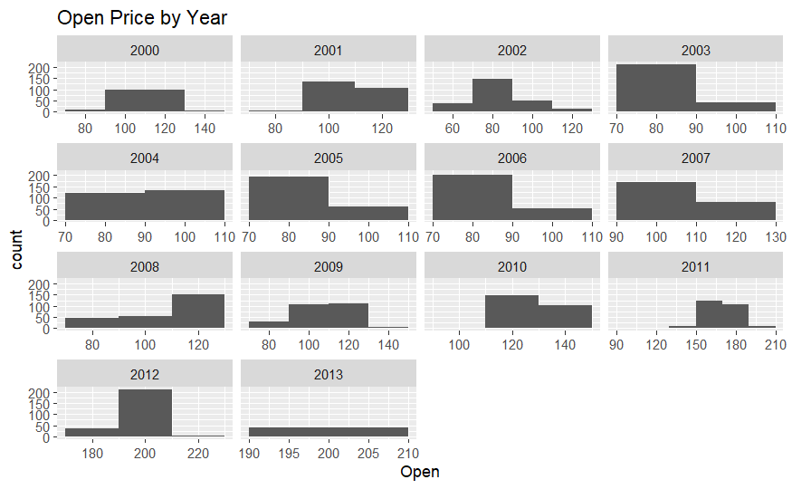

```r
ggplot(IBM, aes(x = Open)) +
  geom_histogram(binwidth = 20) +
  ggtitle("Open Price by Year") +
  facet_wrap(~ year, scales = "free_x")
```

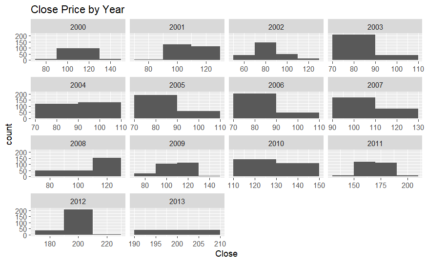

```r
ggplot(IBM, aes(x = Close)) +
  geom_histogram(binwidth = 20) +
  ggtitle("Close Price by Year") +
  facet_wrap(~ year, scales = "free_x")
```

#### **12. Scatter Plot with Regression Line**: Display a scatter plot between the highest and lowest prices, along with a regression line.

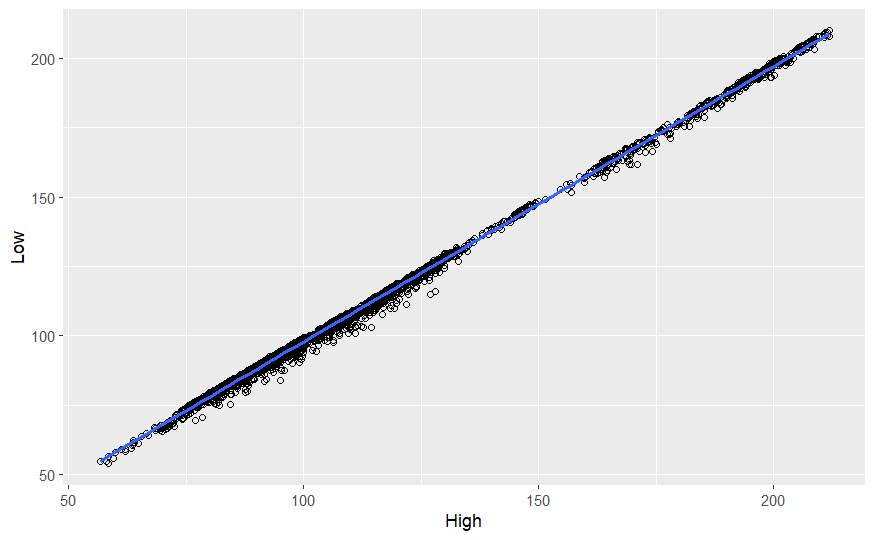

```r
ggplot(IBM,aes(x=High,y=Low)) + geom_point(shape=1) + geom_smooth(method = lm)
```

#### **13. Boxplot**: Obtain a boxplot of the Adj.Close variable for each year.

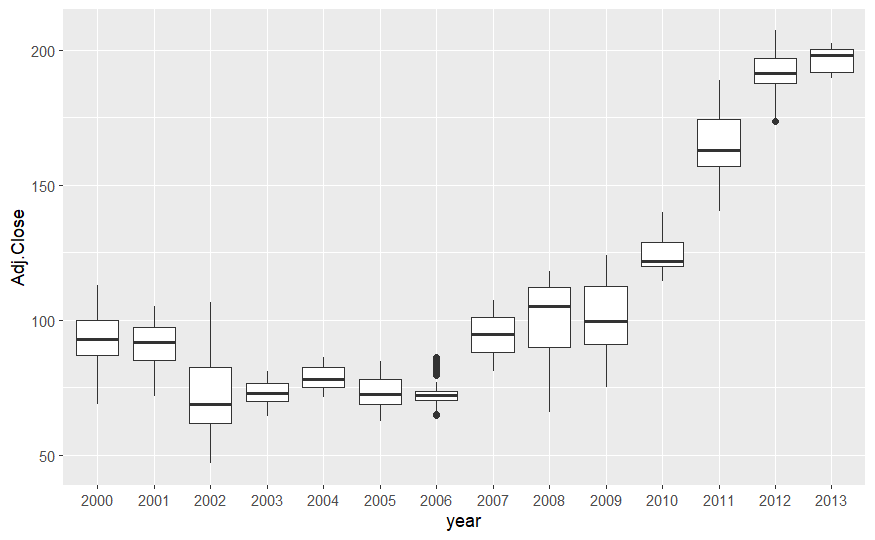

```r
ggplot(IBM,aes(year,Adj.Close)) + geom_boxplot()
```

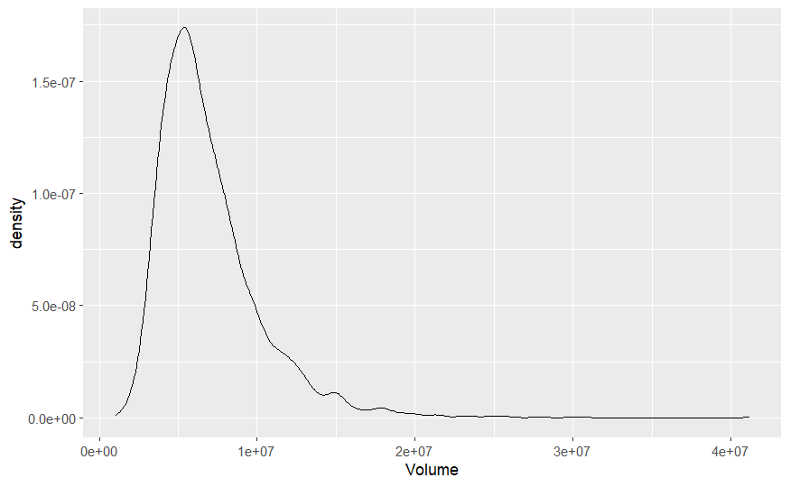

```r
ggplot(IBM, aes(x=Volume)) + geom_density()
```